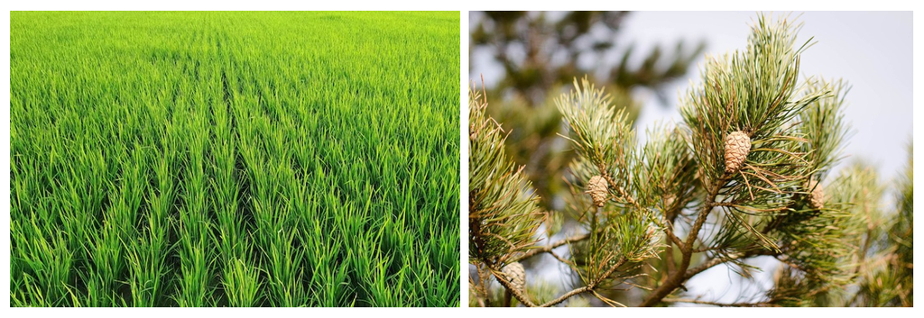

# genomic prediction for GBLUP estimated breeding values (EBVs) associated to rice and pine traits

### 🎯 Objective

This repository contains R scripts designed for reproducible data analysis and results, aligned with the FAIR principles. The scripts perform data reformatting and GBLUP EBVs computation to be used as phenotypes for genomic prediction.

### 💻 Instructions

Download the `double_gblup_analyses` repository in the current user’s directory on a computing cluster or personal computer using one of the following commands :

- `git clone git@github.com:ljacquin/double_gblup_analyses.git`

  ```
  or
  ```

- `git clone https://github.com/ljacquin/double_gblup_analyses.git`

⚠️ Make sure`git` is installed beforehand; if not, install it with `sudo apt install git`.

- Given that `R ≥ 4.1.2` is already installed, within the `double_gblup_analyses` folder use the following command to install and test `double_gblup_analyses` required `R` libraries :
  - `R -q --vanilla < src/requirements.R`
  - `R -q --vanilla < src/test_requirements.R`
- The `R` scripts `*data_reformatting.R`, `*spat_hetero_correct_per_env_trait.R` and `*gblup_ebv_computation.R` in the `double_gblup_*/src/data_treatment_and_analysis/` folders perform 0) data reformatting, 1) spatial heterogeneity correction, and 2) GBLUP EBVs computation.
- The `R` script `double_gblup_*/src/genomic_prediction_and_analysis/genomic_prediction.R` performs, for each trait, the genomic prediction tasks and analyses for the GBLUP EBVs

⚠️ The tasks and analyses performed by the `R` scripts in the `double_gblup_analyses` repository can be run in either `Unix/Linux` or `Windows` environments, as long as `R` and the necessary libraries are installed. For local computations in `RStudio`, ensure that the `computation_mode` variable is set to “local” in the `R` scripts located in `src/`.